### Monitoria 3 - MQO - Unidades de medida, formas funcionais e propriedades estatísticas

Nome: Lucas Martins de Farias Fernandes  
Email: Lucasmffernandes@gmail.com

```r
#setup
library(tidyverse)
library(wooldridge)
library(stargazer)
library(gridExtra)
```

#### **1. Amostra**

```r
# Salvando dados no env
dados <- wooldridge::ceosal1 %>%
  as_tibble() %>%
  filter(salary < 5000)
```

#### **2. Unidades de medida e forma funcional.**

Nesse tópico veremos o impacto da unidade de medida e a forma funcional da regressão sobre os coeficientes que estimamos.

##### **2.1 Efeito de mudanças nas unidades de medida.**

```r
mod_1 <- lm(salary ~ roe,data = dados)
mod_1 %>% summary()
```

```
##
## Call:
## lm(formula = salary ~ roe, data = dados)
##
## Residuals:
##     Min      1Q  Median      3Q     Max
## -1002.5  -389.9  -114.0   259.8  3044.5
##
## Coefficients:
##             Estimate Std. Error t value Pr(>|t|)
## (Intercept)  878.161     93.715   9.371  < 2e-16 ***
## roe           15.303      4.885   3.132  0.00199 **
## ---
## Signif. codes:  0 '***' 0.001 '**' 0.01 '*' 0.05 '.' 0.1 ' ' 1
##
## Residual standard error: 598.5 on 204 degrees of freedom
## Multiple R-squared:  0.04589,    Adjusted R-squared:  0.04122
## F-statistic: 9.813 on 1 and 204 DF,  p-value: 0.001988
```

Da regressão temos:

$\widehat{salary} = 878.161 + 15.3*(roe)$

Interpretando o coeficiente podemos calcular que, se roe = 0, o salário médio é igual ao intercepto, 878.16. Além disso, para um aumento de uma unidade de roe o salário aumenta, em média, 15.3.

Mas o que acontece se mudarmos a unidade de medida ou a forma funcional do nosso modelo? A resposta é que os coeficientes e a forma que interpretamos os resultados mudarão.

No exemplo anterior medimos salário em milhares de dólares. Se ao invés disso, quisermos medir o salário em dólares?

```r
#Criando nova coluna em reais
dados <- dados %>%
  select(salary,roe) %>%
  mutate(salary_dolares = salary * 1000)

mod_2 <- lm(salary_dolares ~ roe,data = dados)
mod_2 %>% summary()
```

```
##
## Call:
## lm(formula = salary_dolares ~ roe, data = dados)
##
## Residuals:
##      Min       1Q   Median       3Q      Max
## -1002542  -389897  -114013   259791  3044474
##
## Coefficients:
##             Estimate Std. Error t value Pr(>|t|)
## (Intercept)   878162      93715   9.371  < 2e-16 ***
## roe            15303       4885   3.132  0.00199 **
## ---
## Signif. codes:  0 '***' 0.001 '**' 0.01 '*' 0.05 '.' 0.1 ' ' 1
##
## Residual standard error: 598500 on 204 degrees of freedom
## Multiple R-squared:  0.04589,    Adjusted R-squared:  0.04122
## F-statistic: 9.813 on 1 and 204 DF,  p-value: 0.001988
```

Podemos observar, portanto, que para uma mesma amostra os valores dos coeficientes são diferentes. Vale destacar, porém, que mudanças na unidade de medida não tem impacto sobre a variação amostral. Logo, nesse caso, o $R^2$ não muda.

##### **2.2 Incorporação de não linearidade na regressão simples.**

Além da unidade de medida, devemos nos atentar a forma funcional da regressão. Até o momento assumimos relações lineares (nos parâmetros) em nossos modelos de regressões simples. Dessa forma, no modelo feito anteriormente, o efeito de roe sobre o salário é constante, e será sempre igual ao $\beta_1$.

Na forma funcional nível-nível não conseguimos capturar relações que sejam marginalmente decrescentes ou crescentes por exemplo. Para melhor estimar essas relações, podemos alterar a forma funcional do nosso modelo, utilizando o log() natural.

**1. Modelo log_nivel**

```r
mod_log_nivel <- lm(log(salary) ~ roe,data = dados)
mod_log_nivel %>% summary()
```

```
##
## Call:
## lm(formula = log(salary) ~ roe, data = dados)
##
## Residuals:
##      Min       1Q   Median       3Q      Max
## -1.58437 -0.29712  0.00845  0.32745  1.44973
##
## Coefficients:
##             Estimate Std. Error t value Pr(>|t|)
## (Intercept) 6.684983   0.075676  88.337  < 2e-16 ***
## roe         0.013505   0.003945   3.423 0.000748 ***
## ---
## Signif. codes:  0 '***' 0.001 '**' 0.01 '*' 0.05 '.' 0.1 ' ' 1
##
## Residual standard error: 0.4833 on 204 degrees of freedom
## Multiple R-squared:  0.05433,    Adjusted R-squared:  0.04969
## F-statistic: 11.72 on 1 and 204 DF,  p-value: 0.0007476
```

A interpretação do coeficiente agora é outra. O coeficiente de roe, $\beta_1$, é lido como uma porcentagem constante. A variação sobre o salario será dada por:

$\% \Delta salary = (100.\beta_1)roe$

Ou seja, um aumento de 1 uma unidade de roe leva a um aumento de 1.35% do salario.

Nesse caso, como a variação percentual é constante para qualquer valor de roe, a variação em salary aumenta para cada unidade de roe. Podemos observar essa relação no gráfico a seguir.

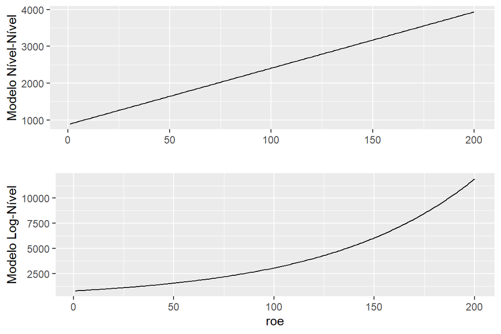

```r
#modelo nivel nivel
b0_nn <- mod_1$coefficients["(Intercept)"]
b1_nn <- mod_1$coefficients["roe"]

#Modelo log nivel
b0_ln <- mod_log_nivel$coefficients["(Intercept)"]
b1_ln <- mod_log_nivel$coefficients["roe"]


plots <- tibble(roe = 1:200) %>%
  mutate(salary_nn = b0_nn + b1_nn*(roe),
         salary_ln = exp(b0_ln + b1_ln*(roe))) %>%
  ggplot(aes(x = roe))

grid.arrange(
  plots + geom_line(aes(y = salary_nn)) + ylab("Modelo Nível-Nível") + xlab(""),
  plots + geom_line(aes(y = salary_ln))+ ylab("Modelo Log-Nível"),
  ncol = 1
)
```

**2. Modelo log-log.**

```r
mod_log_log <- lm(log(salary) ~ log(roe),data = dados)
mod_log_log %>% summary
```

```
##
## Call:
## lm(formula = log(salary) ~ log(roe), data = dados)
##
## Residuals:
##      Min       1Q   Median       3Q      Max
## -1.57282 -0.30317  0.00944  0.32807  1.42028
##
## Coefficients:
##             Estimate Std. Error t value Pr(>|t|)
## (Intercept)  6.49225    0.17303  37.520   <2e-16 ***
## log(roe)     0.15621    0.06239   2.504   0.0131 *
## ---
## Signif. codes:  0 '***' 0.001 '**' 0.01 '*' 0.05 '.' 0.1 ' ' 1
##
## Residual standard error: 0.4895 on 204 degrees of freedom
## Multiple R-squared:  0.02981,    Adjusted R-squared:  0.02506
## F-statistic: 6.269 on 1 and 204 DF,  p-value: 0.01307
```

No modelo log-log obtemos uma estimativa em termos de elasticidade. Ou seja, uma variação de 1% em roe leva a uma variação de 0.15% de salary. Logo:

$\% \Delta y = \beta_{1} \% \Delta x$

Resumo das formas funcionais logaritimicas:

| Modelo | Variavel dependente | Variavel independente | Interpretaçao $\beta_{1}$ |
| --- | --- | --- | --- |
| Nível-Nível | y | x | $\Delta y = \beta_{1}\Delta x$ |
| Nível-log | y | log(x) | $\Delta y = (\beta_{1}/100)\% \Delta x$ |
| Log-Nível | log(y) | x | $\% \Delta y = (100 \beta_{1}) \Delta x$ |
| Log-log | log(y) | log(x) | $\% \Delta y = \beta_{1} \% \Delta x$ |

#### **3. Valores esperados e variâncias dos estimadores.**

Até então assumimos as seguintes hipóteses para estimar os coeficientes do MQO:

**1. Linear nos parâmetros.**

No modelo populacional, a variável dependente y está relacionada à variável independente x e ao erro u como:

$y = \beta_{0} + \beta_{1} x + u$

em que $\beta_{0}$ e $\beta_{1}$ são os parâmetros de intercepto e de inclinação populacionais, respectivamente.

**2. Amostragem aleatória.**

Podemos usar uma amostra aleatória de tamanho $n, \{(x_{i},y_{i}): i =1,2,...,n\}$ proveniente do modelo populacional descrito pela hipótese 1.

Com isso a equação populacional descrita na hipótese 1 pode ser definida em termos da amostra aleatória como:

$y = \beta_{0} + \beta_{1} x_{i} + u_{i},onde: \ i =1,2,...,n$

**3. Média condicional zero.**

O erro u tem valor esperado nulo, dado qualquer valor da variável explicativa, Logo:

$E(u|x) = E(u) = 0$

##### **3.1 Inexistência de viés.**

A partir das três hipóteses apresentadas é possível demonstrar que os estimadores do MQO são não viesados. Em outras palavras, os estimadores do MQO podem errar pontualmente, mas, na média, eles serão iguais. Formalizando:

$E(\hat{\beta_0}) = \beta_0 \ \ , \ \ E(\hat{\beta_1}) = \beta_1$

Podemos demonstrar esse teorema de forma prática:

Postulando uma regressão populacional:

$y = -2 + 3.5x + u$

```r
# Simulando dados
N <- 100000
X <- runif(N, min = 0, max = 20)
u <- rnorm(N, sd = 10)

# Calculando os valores de Y
Y <- -2 + 3.5 * X + u
population <- tibble(X, Y)

# Repetições
reps <- 10000

# Inicializando matriz que registra coeficientes
fit <- matrix(ncol = 2, nrow = reps)

# Rodando 10000 modelos a partir de amostras aleatórias da nossa população.
for (i in 1:reps){

 sample <- population[sample(1:N, 100),]
 fit[i, ] <- lm(Y ~ X, data = sample)$coefficients

}

# Salvando resultados em um data_frame
fit <- fit %>%
  as.data.frame() %>%
  rename("hat_beta0" ="V1",
         "hat_beta1" = "V2")

#Calculando a media dos parametros estimados
mean_hat_beta_0 <- mean(fit[,"hat_beta0",drop = TRUE])
mean_hat_beta_1 <- mean(fit[,"hat_beta1",drop = TRUE])

#Calculando a variancia
var_hat_beta_0 <- var(fit[,"hat_beta0",drop = TRUE])
var_hat_beta_1 <- var(fit[,"hat_beta1",drop = TRUE])

#Observando os valores:
as_vector(c("E(hat_beta_0)" = mean_hat_beta_0,
          "E(hat_beta_1)" = mean_hat_beta_1))
```

```
## E(hat_beta_0) E(hat_beta_1)
##     -1.936330      3.490539
```

Através dessa simulação conseguimos também observar a distribuição dos coeficientes

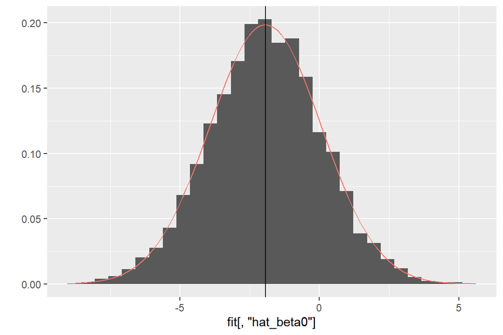

```r
fit %>%
  ggplot(aes(x = fit[,"hat_beta0"])) +
  geom_histogram(aes(y =..density..)) +
  stat_function(fun = dnorm,args = list(mean = mean_hat_beta_0, sd = sqrt(var_hat_beta_0)),aes(color = "darkred")) +
  geom_vline(xintercept = mean_hat_beta_0) +
  guides(color = FALSE) +
  ylab("")
```

> **Exemplo de correlação espúria. Wooldridge Pg 51, Ex 2.12.**

> Quando u contém valores que afetam y e são correlacionados com x, podemos achar uma relação entre y e x viesada. Nesse caso, nossa estimativa está contaminada pelos fatores presentes nos resíduos.

> $math10 = \beta_0 + \beta_1 lnchprg + u$

> math10 corresponde a porcentagem de alunos do primeiro ano do ensino médio aprovados em um exame de matemática. lnchprg corresponde ao porcentual de estudantes que estão aptos para participar > do programa de merenda escolar. Intuitivamente, esperamos que o impacto do programa seja positivo sobre a porcentagem de alunos aprovados. Porém, como veremos na regressão, esse não é o resultado encontrado:

```r
mod_espurio <- lm(math10 ~ lnchprg,data = meap93)
mod_espurio %>% summary
```

```
##
## Call:
## lm(formula = math10 ~ lnchprg, data = meap93)
##
## Residuals:
##     Min      1Q  Median      3Q     Max
## -24.386  -5.979  -1.207   4.865  45.845
##
## Coefficients:
##             Estimate Std. Error t value Pr(>|t|)
## (Intercept) 32.14271    0.99758  32.221   <2e-16 ***
## lnchprg     -0.31886    0.03484  -9.152   <2e-16 ***
## ---
## Signif. codes:  0 '***' 0.001 '**' 0.01 '*' 0.05 '.' 0.1 ' ' 1
##
## Residual standard error: 9.566 on 406 degrees of freedom
## Multiple R-squared:  0.171,  Adjusted R-squared:  0.169
## F-statistic: 83.77 on 1 and 406 DF,  p-value: < 2.2e-16
```

> O coeficiente de lnchprg é negativo, indicando que o programa piora o rendimento dos alunos. Esse resultado pode ser viesado devido a um problema de má especificação do modelo. Ou seja, existem termos correlacionados a x dentro dos residuos da regressão que deveriam estar explícitos no nosso modelo.

##### **3.3 variâncias dos estimadores.**

Anteriormente calculamos a variância dos coeficientes através dos resultados das 10.000 regressões que fizemos. Obviamente que na prática isso não é possível. Para que seja possível estimar a variância adotaremos mais uma hipótese:

**4. Homoscedasticidade.**

O erro u tem a mesma variância, dado qualquer valor da variavel explicativa, x. Logo:

$Var(u|x) = \sigma^2$

Com isso, conseguimos calcular a variância dos parâmetros:

$Var(\hat{\beta_1}) =\frac{\sigma^2}{SQT_x}$

$Var(\hat{\beta_0}) = \frac{\sigma^2 n^-1 \sum_{i = 1}^n{x^2_i}}{\sum_{i = 1}^n{(x_i-\bar{x})^2}} = \frac{\sigma^2 n^-1 \sum_{i = 1}^n{x^2_i}}{SQT_x}$

##### **3.3 Estimação da variância do erro.**

$\sigma^2$ ainda é desconhecido. Para calcular a variância devemos também estima-lo, para isso utilizamos o estimador não viesado de sigma:

$\sigma^2 = \frac{SQR}{(n-2)}$

Temos agora todas as informações necessárias para calcular as variâncias dos coeficientes:

```r
#Calculando Soma dos quadrados dos residuos
SQR <- sum(resid(mod_1)^2)

#Calculando sigma^2
sigma_sq <- SQR / (nrow(dados) - 2)
sigma_sq
```

```
## [1] 358160.3
```

```r
# Erro padrão
sigma_sq %>% sqrt()
```

```
## [1] 598.465
```

**1. Variancia de $\hat{\beta_1}:$**

```r
roe <- dados[,"roe",drop = TRUE]
SQT_x <- sum((roe - mean(roe))^2)
var_hbeta_1 <- sigma_sq/SQT_x
var_hbeta_1
```

```
## [1] 23.86597
```

```r
#erro padrao
var_hbeta_1 %>% sqrt()
```

```
## [1] 4.885281
```

**2. Variancia de $\hat{\beta_0}:$**

```r
n <- nrow(dados)

var_hbeta_0 <- sigma_sq*(n^-1)*sum(roe^2) / SQT_x
var_hbeta_0
```

```
## [1] 8782.422
```

```r
#erro padrao
var_hbeta_0 %>% sqrt()
```

```
## [1] 93.71458
```

**Comparando valores que calculamos com o modelo:**

```r
mod_1 %>% summary()
```

```
##
## Call:
## lm(formula = salary ~ roe, data = dados)
##
## Residuals:
##     Min      1Q  Median      3Q     Max
## -1002.5  -389.9  -114.0   259.8  3044.5
##
## Coefficients:
##             Estimate Std. Error t value Pr(>|t|)
## (Intercept)  878.161     93.715   9.371  < 2e-16 ***
## roe           15.303      4.885   3.132  0.00199 **
## ---
## Signif. codes:  0 '***' 0.001 '**' 0.01 '*' 0.05 '.' 0.1 ' ' 1
##
## Residual standard error: 598.5 on 204 degrees of freedom
## Multiple R-squared:  0.04589,    Adjusted R-squared:  0.04122
## F-statistic: 9.813 on 1 and 204 DF,  p-value: 0.001988
```